# CSC 453

Spring 2026 - Day 2

## Admin

- Lab 1 due Thursday, 11:59 PM
- Assignment 1 due April 15

# OS abstractions

## Questions to consider

- What are the main abstractions OSes provide?
- What are the abstraction challenges?

## Abstractions

- Abstractions *simplify application design* by:
  - hiding undesirable properties,
  - adding new capabilities, and
  - organizing information
- Abstractions provide an interface to application programmers that separates policy—what the interface commits to accomplishing—from mechanism—how the interface is implemented.

## What are the abstractions?

- CPUs
  - Processes, threads
- Memory
  - Address space
- Disk
  - Files

## Example OS abstraction: file systems

- What undesirable properties do file systems hide?
  - Disks are slow!
  - Chunks of storage are actually distributed all over the disk
  - Disk storage may fail!
- What new capabilities do files add?
  - Growth and shrinking
  - Organization into directories, searchability
- What information do files help organize?
  - Ownership and permissions
  - Access time, modification time, type, etc.

## Abstraction tradeoffs - discussion

- Identify undesirable properties hidden by, new capabilities added, and info organization provided with these abstractions:
  - Process / threads
  - Address space

## Abstraction pros / cons

- Advantages of OS providing abstractions?
  - Allow applications to reuse common facilities
  - Make different devices look the same
  - Provide higher-level or more useful functionality
- Challenges?
  - What are the correct abstractions?
  - How much should be exposed?

## OS design requirements - what do we need?

- Convenience, abstraction of hardware resources for user programs
- Efficiency of usage of CPU, memory, etc.
- Isolation between multiple processes
- Reliability, the OS must not fail
- Other:
  - Security
  - Mobility

What isn’t clear?

Comments? Thoughts?

# Resource management

## Questions to consider

- How does the OS manage access to resources?

## OS as a resource manager

- Another view: resource manager - shares resources “well”
- Advantages of the OS managing resources?
  - Protect applications from one another
  - Provide efficient access to resources (cost, time, energy)
  - Provide fair access to resources
- Challenges?
  - What are the correct mechanisms?
  - What are the correct policies?

## Resources are managed via services

- Program Execution (loading, running, monitoring, terminating)
- Performance (optimizing resources under constraints)
- Correctness (overseeing critical operations, preventing interference)
- Fairness (access to and allocation of resources)
- Error detection & recovery (network partition & media failure)

## Services (cont’d)

- Communication (inter-process, software-to-hardware, hardware-to-hardware, system-to-system, wide-area)
- I/O: reading & writing, support for various mediums, devices, performance, and protections
- Data Organization (naming), Services (search) & Protection (access control)
- Security (isolation, enforcement, services, authentication, accounting and logging, trust)
- User interfaces (command-line, GUIs, multiple users)

## Each service has challenges and tensions

Example 1: We have limited RAM, and we want to run more programs that can be stored.

- How do we allocate space?
- Who stays?
- Who goes?
- What if we’re wrong?
- What if the system is under extremely heavy load?
- Is there a way to predict the future?

## Each service has challenges and tensions

Example 2: We have two processes (producer / consumer); how do they communicate?

- Message passing? Shared memory?
- How do they synchronize?
  - How do we prevent over-production? Over-consumption?
  - Context-switching?

What isn’t clear?

Comments? Thoughts?

# Boot chain

## Questions to consider

- What is the chain of events that takes place before you are able to run a process?
- Where do the different parts of the chain reside? How are they called?

## Boot is like a relay race

- A sequence of programs
- Each stage:
  - Has slightly more power
  - Loads the next stage
  - Jumps to it

## Power-On

- CPU resets
- Instruction pointer set to a fixed address
- Execution begins in firmware (ROM)
- The CPU does not know what an OS is

## Firmware (BIOS / UEFI)

- Initializes RAM
- Initializes minimal hardware
- Finds one program to run (bootloader)
- Loads it into memory
- Jumps to it

## Bootloader’s job (GRUB Example)

- Understand filesystems
- Load the kernel image
- Load the initramfs
- Jump to the kernel entry point
- Provides kernel command line args

  ```
  root=/dev/sda1
  init=/sbin/init
  console=ttyS0
  ```

## What the bootloader does not do

- Does not schedule processes
- Does not manage memory long-term
- Does not run the OS

## Kernel

Think of the kernel in phases

1. Self-setup
2. Hardware abstraction
3. Userspace handoff

## Kernel self-setup

- Sets up page tables
- Enables virtual memory
- Initializes scheduler
- Sets up interrupts

The kernel cannot rely on anything yet: it is building the world.

## Kernel hardware abstractions

### This is where hardware becomes an abstraction.

- Detects hardware
- Loads drivers
- Turns devices into files:
  - `/dev/sda`
  - `/dev/tty`
- Creates kernel threads

## Userspace handoff

- Mounts the root filesystem
- Chooses one program to run
- Executes it with `execve()`

  ```c
  execve("/sbin/init", ...);
  ```

## Init (PID 1)

- First userspace process
- Always PID 1
- Parent of all other processes

If PID 1 exits?

- The kernel panics or shuts down

What isn’t clear?

Comments? Thoughts?

# Kernel basics

## Questions to consider

- What are the different kernel paradigms?
- Why would you choose one over the other?

## Paradigms

- The OS offers a number of services. What should go in the kernel?
  - IPC
  - VFS
  - File system
  - Scheduler
  - Virtual Memory
  - Device drivers

## Monolithic kernels

- Oldest, very common design (Linux, Windows 9x, BSDs)
- Single piece of code in memory
- Limited information hiding
  - One part of the kernel can directly access data and functions of other parts

## Monolithic kernels (cont’d)

- Q: What happens when you need something new supported (new hardware device, new system call, new filesystem)?
- Modules (loadable kernel modules - LKMs) allow for flexibility, customization, support
  - Pros?
    - Memory savings
    - Flexibility
    - Minimal downtime
  - Cons?
    - (minor) fragmentation: the base kernel can be loaded contiguously in memory
    - Security (https://github.com/m0nad/Diamorphine **DO NOT USE THIS, IT’S SIMPLY TO SHOW YOU**)

## Microkernels

- Popular research area long ago, didn’t win (although people remain interested in the principles)
- All non-essential components removed from the kernel, for modularization, extensibility, isolation, security, and ease of management
- A collection of OS services running in user space
- Downsides?
  - **Heavy communication costs** through message passing (marshaled through the kernel)

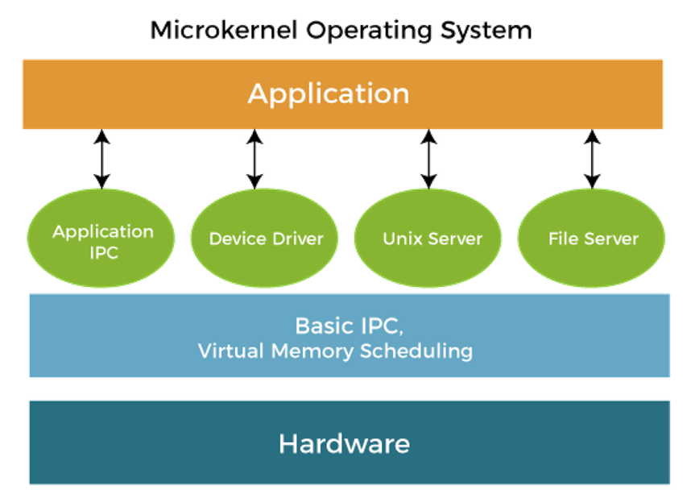

## Monolithic vs Microkernel

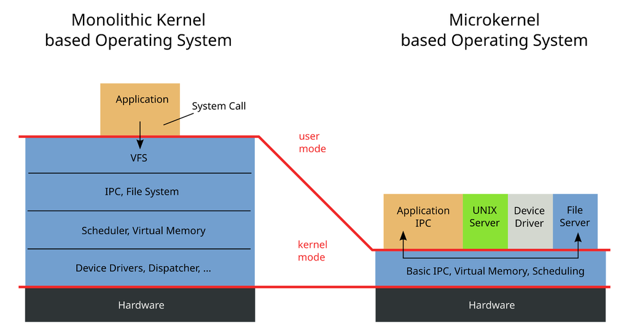

## Hybrid kernels

- Combine a monolithic core with microkernel ideas
- Small kernel handles critical services (scheduling, IPC, low-level memory)
- Other services (file systems, drivers) can run in kernel *or* user space
- Examples: macOS (XNU), Windows NT
  - XNU: Mach microkernel + BSD monolithic layer
  - Windows NT: microkernel-inspired, but most services run in kernel mode for performance
- Pragmatic compromise: microkernel isolation where it matters, monolithic speed where it doesn’t

What isn’t clear?

Comments? Thoughts?